# Data Analysis

Alina Cherkas

2020-06-06

## Introduction

The notebook can be used to replicate the results of the analysis in *The Effects of Migration on Attitudes towards the European Union: Extent, Dynamics and Causality*, master’s thesis submitted to CEU in a.y. 2019/2020. In the analysis, two datasets are used:

1. `DatasetFinal` from `CEU_Thesis_Data.xlsx`, a panel country-level dataset.
2. `CEU_Thesis_Multilevel.feather`, a cross-section of multi-level data (individual, regional and country levels).

The first dataset **can be replicated** in its whole using `1.1. Data Preparation Country.ipynb`. Due to data sharing restrictions, individual-level records used to construct the second dataset are not provided. Thus, the second dataset **cannot be replicated**, but the code used to build it can be found in `1.2. Data Preparation Multilevel.ipynb`. The script also contains a link to the original data source, from which the records can be requested.

The below code can be run step-by-step to replicate the main results of the study. However, the code in sections `Multilevel Data`, `Table 6` and `Table 7` is only for demonstration purposes, since no data are provided for replication as described above.

## Prerequisites

**Note:** you might need to install some of the packages below befor running the code.

```r
# Standard Imports
library(tidyverse)
library(magrittr)

# Input/Output
library(readxl)
library(feather)

# For tables and graphs
library(stargazer)
library(ggdag)
library(dagitty)

# For Panel Models
library(plm)

# For Clustered Stanrard Errors
library(clubSandwich)

# For multilevel models
library(lme4)
```

## Dataset

```r
df.Main <- read_excel("CEU_Thesis_Data.xlsx", sheet = "DatasetFinal")
df.Main %<>% pdata.frame(index = c("Country", "Year"))
```

```r
df_lambda <- df.Main %>% select(Country, Year, ImmigrantStock, InflowsOECD, InflowsEurostat, ShiftShare,
                                 Positive, Negative, VeryNegative)

get_mean <- function(x){mean(x,na.rm=TRUE) %>% round(3)}

DT::datatable(df_lambda %>% select(-Year) %>% group_by(Country) %>% summarise_each(get_mean),
              caption = "Table X. Mean Country-level Values of Main Variables in the Full Dataset (2009-2017)",
              extensions = c('FixedColumns',"FixedHeader")
              )
```

|  | Country | ImmigrantStock | InflowsOECD | InflowsEurostat | ShiftShare | Positive | Negative | VeryNegative |
| --- | --- | --- | --- | --- | --- | --- | --- | --- |
| 1 | Austria | 12.305 | 1.578 | 1.225 | 1.22 | 29.185 | 33.731 | 8.42 |
| 2 | Belgium | 10.859 | 1.03 | 1.181 |  | 40.396 | 21.864 | 3.246 |
| 3 | Bulgaria | 6.122 | 0.446 | 0.304 |  | 54.641 | 13.148 | 3.119 |
| 4 | Denmark | 6.91 | 0.767 | 1.109 |  | 36.641 | 18.317 | 3.719 |
| 5 | Estonia | 16.047 | 0.281 | 0.581 |  | 38.377 | 10.282 | 1.497 |
| 6 | Finland | 3.573 | 0.409 | 0.557 | 0.424 | 30.679 | 22.786 | 3.159 |
| 7 | France | 6.264 | 0.363 | 0.514 |  | 37.687 | 25.014 | 5.608 |
| 8 | Germany | 9.459 | 1.457 | 0.947 | 1.273 | 37.186 | 21.245 | 3.981 |
| 9 | Greece | 6.602 | 0.542 | 0.658 | 0.705 | 26.21 | 39.44 | 13.89 |
| 10 | Hungary | 1.646 | 0.253 | 0.437 | 0.56 | 35.654 | 21.286 | 4.956 |

[output cut: 12 more lines]

```r
DT::datatable(df_lambda %>% select(-Country) %>% group_by(Year) %>% summarise_each(get_mean),
              caption = "Table X. Mean Yearly Values of Main Variables in the Full Dataset (2009-2017)",
              extensions = c('FixedColumns',"FixedHeader")
              )
```

|  | Year | ImmigrantStock | InflowsOECD | InflowsEurostat | ShiftShare | Positive | Negative | VeryNegative |
| --- | --- | --- | --- | --- | --- | --- | --- | --- |
| 1 | 2009 | 8.544 | 0.695 | 0.776 | 0.613 | 46.501 | 14.705 | 2.97 |
| 2 | 2010 | 8.473 | 0.638 | 0.765 | 0.626 | 40.751 | 18.27 | 3.421 |
| 3 | 2011 | 8.563 | 0.694 | 0.822 | 0.657 | 35.547 | 22.54 | 4.506 |
| 4 | 2012 | 8.881 | 0.705 | 0.8 | 0.661 | 31.04 | 27.583 | 6.174 |
| 5 | 2013 | 9.044 | 0.736 | 0.819 | 0.697 | 31.169 | 27.105 | 6.279 |
| 6 | 2014 | 9.167 | 0.799 | 0.891 | 0.788 | 37.764 | 22.543 | 5.049 |
| 7 | 2015 | 9.368 | 0.927 | 1.048 | 1.045 | 39.218 | 20.25 | 4.179 |
| 8 | 2016 | 9.672 | 0.922 | 1.02 | 0.951 | 35.726 | 23.932 | 5.378 |
| 9 | 2017 | 9.863 | 0.95 | 1.033 | 0.885 | 41.471 | 19.414 | 4.197 |

```r
DT::datatable(df_lambda %>% filter(Country != "Luxembourg") %>% select(-Country) %>% group_by(Year) %>%
                summarise_each(get_mean),
              caption = "Table X. Mean Yearly Values of Main Variables in the Full Dataset without Luxembourg (2009-2017)",
              extensions = c('FixedColumns',"FixedHeader")
              )
```

|  | Year | ImmigrantStock | InflowsOECD | InflowsEurostat | ShiftShare | Positive | Negative | VeryNegative |
| --- | --- | --- | --- | --- | --- | --- | --- | --- |
| 1 | 2009 | 6.695 | 0.587 | 0.648 | 0.613 | 45.816 | 14.961 | 3.018 |
| 2 | 2010 | 6.742 | 0.518 | 0.634 | 0.626 | 40.333 | 18.429 | 3.509 |
| 3 | 2011 | 6.837 | 0.549 | 0.665 | 0.657 | 35.071 | 22.764 | 4.611 |
| 4 | 2012 | 7.218 | 0.562 | 0.652 | 0.661 | 30.683 | 27.712 | 6.218 |
| 5 | 2013 | 7.357 | 0.596 | 0.671 | 0.697 | 30.801 | 27.271 | 6.31 |
| 6 | 2014 | 7.447 | 0.655 | 0.74 | 0.788 | 37.362 | 22.638 | 5.157 |
| 7 | 2015 | 7.626 | 0.78 | 0.896 | 1.045 | 38.77 | 20.323 | 4.236 |
| 8 | 2016 | 7.908 | 0.788 | 0.879 | 0.951 | 35.242 | 24.099 | 5.469 |
| 9 | 2017 | 8.064 | 0.808 | 0.886 | 0.885 | 40.74 | 19.549 | 4.247 |

```r
df_lambda <- df.Main %>% filter(IV_Sample == TRUE) %>%
  select(Country, Year, ImmigrantStock, InflowsOECD, InflowsEurostat, ShiftShare, Positive, Negative, VeryNegative)

DT::datatable(df_lambda %>% select(-Year) %>% group_by(Country) %>% summarise_each(get_mean),
              caption = "Table X. Mean Country-level Values of Main Variables in the IV Subset (2009-2017)",
              extensions = c('FixedColumns',"FixedHeader")
              )
```

|  | Country | ImmigrantStock | InflowsOECD | InflowsEurostat | ShiftShare | Positive | Negative | VeryNegative |
| --- | --- | --- | --- | --- | --- | --- | --- | --- |
| 1 | Austria | 12.305 | 1.578 | 1.225 | 1.22 | 29.185 | 33.731 | 8.42 |
| 2 | Finland | 3.573 | 0.409 | 0.557 | 0.424 | 30.679 | 22.786 | 3.159 |
| 3 | Germany | 9.459 | 1.457 | 0.947 | 1.273 | 37.186 | 21.245 | 3.981 |
| 4 | Italy | 7.289 | 0.529 | 0.585 | 0.57 | 39.134 | 22.575 | 4.565 |
| 5 | Netherlands | 4.852 | 0.817 | 0.876 | 0.473 | 36.524 | 24.413 | 3.581 |
| 6 | Spain | 10.595 | 0.696 | 0.789 | 0.783 | 33.359 | 20.689 | 3.941 |
| 7 | Sweden | 7.156 | 1.044 | 1.253 | 0.916 | 36.364 | 25.09 | 4.172 |

```r
DT::datatable(df_lambda %>% select(-Country) %>% group_by(Year) %>% summarise_each(get_mean),
              caption = "Table X. Mean Yearly Values of Main Variables in the IV Subset (2009-2017)",
              extensions = c('FixedColumns',"FixedHeader")
              )
```

|  | Year | ImmigrantStock | InflowsOECD | InflowsEurostat | ShiftShare | Positive | Negative | VeryNegative |
| --- | --- | --- | --- | --- | --- | --- | --- | --- |
| 1 | 2009 | 7.009 | 0.742 | 0.744 | 0.635 | 44.639 | 16.207 | 2.415 |
| 2 | 2010 | 7.193 | 0.754 | 0.742 | 0.653 | 37.46 | 20.345 | 3.53 |
| 3 | 2011 | 7.379 | 0.796 | 0.77 | 0.693 | 33.313 | 24.796 | 4.148 |
| 4 | 2012 | 7.564 | 0.831 | 0.782 | 0.709 | 27.625 | 30.83 | 6.005 |
| 5 | 2013 | 7.768 | 0.877 | 0.822 | 0.751 | 27.332 | 30.696 | 6.381 |
| 6 | 2014 | 7.999 | 0.973 | 0.905 | 0.828 | 34.073 | 25.564 | 4.86 |
| 7 | 2015 | 8.263 | 1.191 | 1.137 | 1.068 | 35.821 | 23.644 | 4.195 |
| 8 | 2016 | 8.699 | 1.161 | 1.077 | 1.006 | 32.163 | 26.76 | 5.474 |
| 9 | 2017 | 9.133 | 1.071 | 1.033 | 0.934 | 39.271 | 20.408 | 3.902 |

## Table 1

Replication can be found in `1.1. Data Preparation Country.ipynb`

## Figure 1

The figure was created using *Tableau Desktop (2020.2)* based on `DatasetFinal` from `CEU_Thesis_Data.xlsx`. Replication codes are not applicable.

## Figure 2

The figure was created using *Tableau Desktop (2020.2)* based on `DatasetFinal` from `CEU_Thesis_Data.xlsx`. Replication codes are not applicable.

## Figure 3

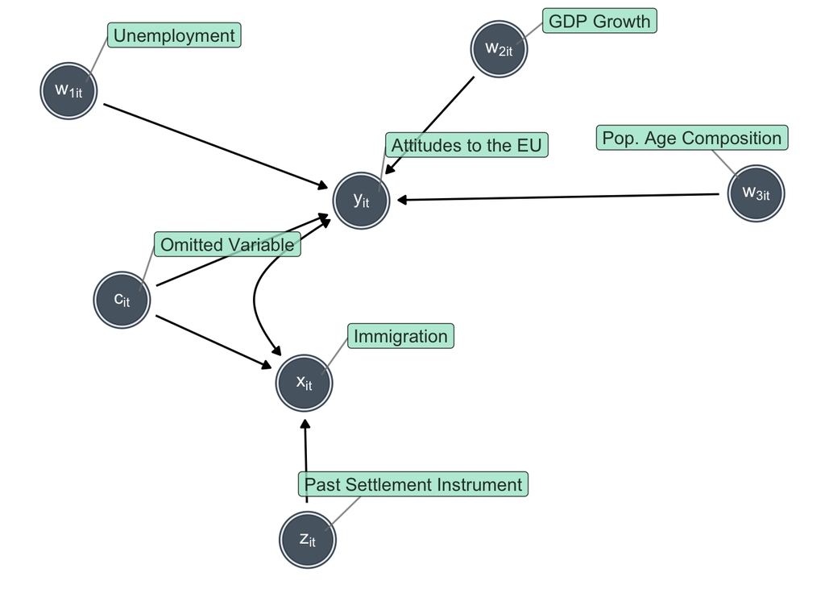

Figure 3. Directed Graph of the Causal Relationship between Immigration and Attitudes

```r
g <- dagify(y_it ~ c_it + w_1it + w_2it + w_3it,
            y_it ~~ x_it,
            x_it ~ c_it + z_it)

to_labels <- c(expression(c[it]),
               expression(w[1][it]),
               expression(w[2][it]),
               expression(w[3][it]),
               expression(x[it]),
               expression(z[it]),
               expression(y[it]))

g %>% tidy_dagitty() %>% dag_label(labels = c("y_it" = "Attitudes to the EU",
                                              "x_it" = "Immigration",
                                              "c_it" = "Omitted Variable",
                                              "z_it" = "Past Settlement Instrument",
                                              "w_1it" = "Unemployment",
                                              "w_2it" = "GDP Growth",
                                              "w_3it" = "Pop. Age Composition"
                                              )) %>%
  ggplot(aes(x = x, y = y, xend = xend, yend = yend)) +
  geom_dag_edges() +
  geom_dag_node(color = "#2c3e50", alpha = 0.8) +
  geom_dag_text(color = "white",
                parse = TRUE,
                label = to_labels) +
  geom_dag_label_repel(aes(label = label),
                       fill = "#a8e6cf",
                       alpha = 0.8,
                       nudge_x = .3,
                       nudge_y = .3) +
  theme_void() + theme()
```

## Figure 4

Replication can be found in `1.1. Data Preparation Country.ipynb`.

## Table 2

```r
purtest(InflowsOECD ~ 1, data = df.Main, index = "Country", lag = 0, test = "levinlin")
```

```
##
##  Levin-Lin-Chu Unit-Root Test (ex. var.: Individual Intercepts)
##
## data:  InflowsOECD ~ 1
## z = -2.4309, p-value = 0.007531
## alternative hypothesis: stationarity
```

```r
purtest(InflowsOECD ~ 1, data = df.Main, index = "Country", lag = 1, test = "levinlin")
```

```
##
##  Levin-Lin-Chu Unit-Root Test (ex. var.: Individual Intercepts)
##
## data:  InflowsOECD ~ 1
## z = -1.9053, p-value = 0.02837
## alternative hypothesis: stationarity
```

```r
purtest(InflowsOECD ~ 1, data = df.Main, index = "Country", lag = 0, test = "ips")
```

```
##
##  Im-Pesaran-Shin Unit-Root Test (ex. var.: Individual Intercepts)
##
## data:  InflowsOECD ~ 1
## Wtbar = 0.19853, p-value = 0.5787
## alternative hypothesis: stationarity
```

```r
purtest(InflowsOECD ~ 1, data = df.Main, index = "Country", lag = 1, test = "ips")
```

```
##
##  Im-Pesaran-Shin Unit-Root Test (ex. var.: Individual Intercepts)
##
## data:  InflowsOECD ~ 1
## Wtbar = 0.24476, p-value = 0.5967
## alternative hypothesis: stationarity
```

```r
# Complete Pooling
m.OLS1 <- plm(VeryNegative ~ InflowsOECD + ImmigrantStock + UnempRate, data = df.Main, model = "pooling")
m.OLS2 <- update(m.OLS1, .~. + GlobalExposure + GDP_Growth)
m.OLS3 <- update(m.OLS2, .~. + EduShare + Pop25_49 +  PopOver65)

# Clustered Standard Errors
m.OLS1_se <- coef_test(m.OLS1, vcov = "CR1", cluster = "individual")
m.OLS2_se <- coef_test(m.OLS2, vcov = "CR1", cluster = "individual")
m.OLS3_se <- coef_test(m.OLS3, vcov = "CR1", cluster = "individual")
```

```r
# Fixed-Effects
m.FE1 <- update(m.OLS3, model = "within", effect = "twoways")
m.FE2 <- update(m.FE1, .~. - InflowsOECD + lag(InflowsOECD,1))
m.FE3 <- update(m.FE1, .~. + lag(InflowsOECD,1))

# Clustered Standard Errors
m.FE1_se <- coef_test(m.FE1, vcov = "CR1", cluster = "individual")
m.FE2_se <- coef_test(m.FE2, vcov = "CR1", cluster = "individual")
m.FE3_se <- coef_test(m.FE3, vcov = "CR1", cluster = "individual")
```

```r
stargazer(m.OLS1, m.OLS2, m.OLS3, m.FE1, m.FE2, m.FE3, type = "html", style = "apsr",
          se = list(m.OLS1_se$SE, m.OLS2_se$SE, m.OLS3_se$SE, m.FE1_se$SE, m.FE2_se$SE, m.FE3_se$SE),
          title = "Table 2. Baseline Results for 22 European Countries (2009-2017)",
          column.labels =  c("Complete Pooling", "Fixed-Effects"),
          column.separate = c(3, 3),
          model.numbers = TRUE,
          dep.var.labels = "Share of Population with Very Negative Attitude towards the EU",
          covariate.labels = c("Immigrant Flows",
                               "Immigrant Stock",
                               "Unemployment Rate",
                               "Globalisation Exposure",
                               "GDP Growth (in %)",
                               "Education (in %) ",
                               "Share Aged 25-49",
                               "Share Aged Over 65",
                               "Immigrant Flows (1-year lag)")
          )
```

**Table 2. Baseline Results for 22 European Countries (2009-2017)**

|  | Share of Population with Very Negative Attitude towards the EU |  |  |  |  |  |
| --- | --- | --- | --- | --- | --- | --- |
|  | Complete Pooling |  |  | Fixed-Effects |  |  |
|  | (1) | (2) | (3) | (4) | (5) | (6) |
| Immigrant Flows | 2.440** | 2.159* | 1.937* | 1.308** |  | 0.962 |
|  | (1.121) | (1.155) | (1.175) | (0.530) |  | (0.606) |
| Immigrant Stock | -0.173** | -0.161** | -0.163** | -0.552*** | -0.617*** | -0.591*** |
|  | (0.074) | (0.073) | (0.075) | (0.151) | (0.155) | (0.154) |
| Unemployment Rate | 0.503 | 0.407 | 0.362 | 0.890*** | 0.888*** | 0.894*** |
|  | (0.366) | (0.361) | (0.388) | (0.109) | (0.108) | (0.106) |
| Globalisation Exposure |  | -0.017 | -0.018 | 0.039** | 0.039* | 0.040** |
|  |  | (0.014) | (0.016) | (0.020) | (0.021) | (0.020) |
| GDP Growth (in %) |  | -0.052* | -0.164*** | 0.003 | 0.002 | 0.002 |
|  |  | (0.030) | (0.041) | (0.021) | (0.021) | (0.021) |
| Education (in %) |  |  | 0.059 | -0.032 | -0.032 | -0.035 |
|  |  |  | (0.134) | (0.091) | (0.092) | (0.089) |
| Share Aged 25-49 |  |  | 0.008 | 0.873*** | 0.838*** | 0.869*** |
|  |  |  | (0.466) | (0.242) | (0.243) | (0.245) |
| Share Aged Over 65 |  |  | 0.028 | -0.339 | -0.247 | -0.258 |
|  |  |  | (0.221) | (0.335) | (0.359) | (0.360) |
| Immigrant Flows (1-year lag) |  |  |  |  | 1.176** | 0.619 |
|  |  |  |  |  | (0.560) | (0.667) |
| Constant | 1.232 | 3.527 | 2.277 |  |  |  |
|  | (2.437) | (3.276) | (20.004) |  |  |  |
| N | 194 | 194 | 174 | 174 | 174 | 174 |
| R<sup>2</sup> | 0.164 | 0.209 | 0.265 | 0.448 | 0.443 | 0.452 |
| Adjusted R<sup>2</sup> | 0.151 | 0.188 | 0.229 | 0.303 | 0.297 | 0.303 |
| F Statistic | 12.413*** (df = 3; 190) | 9.909*** (df = 5; 188) | 7.434*** (df = 8; 165) | 13.914*** (df = 8; 137) | 13.628*** (df = 8; 137) | 12.449*** (df = 9; 136) |
| p < .1; p < .05; p < .01 |  |  |  |  |  |  |

## Table 3

For first-stage results, see Annex A.

```r
df.IV <- df.Main %>% filter(IV_Sample == TRUE)
df.IV %<>% pdata.frame(index = c("Country", "Year"))
```

```r
purtest(ShiftShare ~ 1, data = df.IV, index = "Country", lag =0, test = "levinlin")
```

```
##
##  Levin-Lin-Chu Unit-Root Test (ex. var.: Individual Intercepts)
##
## data:  ShiftShare ~ 1
## z = -0.79952, p-value = 0.212
## alternative hypothesis: stationarity
```

```r
purtest(ShiftShare ~ 1, data = df.IV, index = "Country", lag =1, test = "levinlin")
```

```
##
##  Levin-Lin-Chu Unit-Root Test (ex. var.: Individual Intercepts)
##
## data:  ShiftShare ~ 1
## z = -1.7589, p-value = 0.0393
## alternative hypothesis: stationarity
```

```r
purtest(ShiftShare ~ 1, data = df.IV, index = "Country", lag = 0, test = "ips")
```

```
##
##  Im-Pesaran-Shin Unit-Root Test (ex. var.: Individual Intercepts)
##
## data:  ShiftShare ~ 1
## Wtbar = 1.5978, p-value = 0.945
## alternative hypothesis: stationarity
```

```r
purtest(ShiftShare ~ 1, data = df.IV, index = "Country", lag = 1, test = "ips")
```

```
##
##  Im-Pesaran-Shin Unit-Root Test (ex. var.: Individual Intercepts)
##
## data:  ShiftShare ~ 1
## Wtbar = 0.51817, p-value = 0.6978
## alternative hypothesis: stationarity
```

```r
# Fixed Effects
m.FE4 <- plm(VeryNegative ~ InflowsOECD + ImmigrantStock + UnempRate + Pop25_49, data = df.IV, model = "within",
             effect = "twoways")
m.FE5 <- update(m.FE4, .~. + GDP_Growth + GlobalExposure)
m.FE6 <- update(m.FE5, .~. + lag(InflowsOECD,1))

# First Stage
m.1stage1 <- plm(InflowsOECD ~ ShiftShare + ImmigrantStock + UnempRate,
                 data = df.IV, model = "within", effect = "twoways")
m.1stage2 <- update(m.1stage1, .~. + Pop25_49 + GDP_Growth + GlobalExposure)

# IV Fixed Effects
m.IVFE1 <- update(m.FE4, .~. -InflowsOECD +  fitted(m.1stage1))
m.IVFE2 <- update(m.FE5, .~. -InflowsOECD + fitted(m.1stage2))
m.IVFE3 <- update(m.IVFE2, .~. + lag(fitted(m.1stage2),1))

# Clustered Standard Errors
m.FE4_SE <- coef_test(m.FE4, vcov = "CR1", cluster = "individual", test = "Satterthwaite")
m.FE5_SE <- coef_test(m.FE5, vcov = "CR1", cluster = "individual", test = "Satterthwaite")
m.FE6_SE <- coef_test(m.FE6, vcov = "CR1", cluster = "individual", test = "Satterthwaite")
m.IVFE1_SE <- coef_test(m.IVFE1, vcov = "CR1", cluster = "individual", test = "Satterthwaite")
m.IVFE2_SE <- coef_test(m.IVFE2, vcov = "CR1", cluster = "individual", test = "Satterthwaite")
m.IVFE3_SE <- coef_test(m.IVFE3, vcov = "CR1", cluster = "individual", test = "Satterthwaite")
```

```r
stargazer(m.FE4, m.FE5, m.FE6, m.IVFE1, m.IVFE2, m.IVFE3, type = "html", style = "apsr",
          se = list(m.FE4_SE$SE, m.FE5_SE$SE, m.FE6_SE$SE, m.IVFE1_SE$SE, m.IVFE2_SE$SE, m.IVFE3_SE$SE),
          title = "Table 3. Main Results for a Subset of 7 European Countries (2009-2017)",
          column.labels =  c("Fixed-Effects", "IV Fixed-Effects"),
          column.separate = c(3, 3),
          model.numbers = TRUE,
          dep.var.labels = "Share of Population with Very Negative Attitude towards the EU",
          covariate.labels = c("Immigrant Flows",
                               "Immigrant Stock",
                               "Unemployment Rate",
                               "Share Aged 25-49",
                               "GDP Growth (in %)",
                               "Globalisation Exposure",
                               "Immigrant Flows (1-year lag)",
                               "Immigrant Flows (IV)",
                               "Immigrant Flows (IV)",
                               "Immigrant Flows (IV, 1-year lag)")
          )
```

**Table 3. Main Results for a Subset of 7 European Countries (2009-2017)**

|  | Share of Population with Very Negative Attitude towards the EU |  |  |  |  |  |
| --- | --- | --- | --- | --- | --- | --- |
|  | Fixed-Effects |  |  | IV Fixed-Effects |  |  |
|  | (1) | (2) | (3) | (4) | (5) | (6) |
| Immigrant Flows | 1.573*** | 1.638*** | 2.002*** |  |  |  |
|  | (0.400) | (0.357) | (0.497) |  |  |  |
| Immigrant Stock | 0.021 | 0.004 | -0.072 | -0.082 | -0.131 | -0.337 |
|  | (0.122) | (0.126) | (0.223) | (0.139) | (0.154) | (0.217) |
| Unemployment Rate | 0.896*** | 0.923*** | 1.065*** | 1.095*** | 1.113*** | 1.315*** |
|  | (0.100) | (0.104) | (0.176) | (0.188) | (0.206) | (0.224) |
| Share Aged 25-49 | -0.569*** | -0.658*** | -0.715*** | -0.715*** | -0.639*** | -0.673*** |
|  | (0.150) | (0.160) | (0.159) | (0.088) | (0.160) | (0.250) |
| GDP Growth (in %) |  | 0.001 | -0.032 |  | 0.012 | -0.002 |
|  |  | (0.023) | (0.029) |  | (0.031) | (0.043) |
| Globalisation Exposure |  | -0.019 | -0.003 |  | -0.030** | -0.036 |
|  |  | (0.013) | (0.019) |  | (0.014) | (0.025) |
| Immigrant Flows (1-year lag) |  |  | -0.545 |  |  |  |
|  |  |  | (0.732) |  |  |  |
| Immigrant Flows (IV) |  |  |  | 2.853*** |  |  |
|  |  |  |  | (1.087) |  |  |
| Immigrant Flows (IV) |  |  |  |  | 2.788** | 2.842* |
|  |  |  |  |  | (1.139) | (1.480) |
| Immigrant Flows (IV, 1-year lag) |  |  |  |  |  | 0.188 |
|  |  |  |  |  |  | (1.083) |
| N | 63 | 63 | 56 | 63 | 63 | 56 |
| R<sup>2</sup> | 0.544 | 0.548 | 0.561 | 0.522 | 0.522 | 0.529 |
| Adjusted R<sup>2</sup> | 0.357 | 0.332 | 0.311 | 0.326 | 0.294 | 0.260 |
| F Statistic | 13.117*** (df = 4; 44) | 8.477*** (df = 6; 42) | 6.399*** (df = 7; 35) | 12.001*** (df = 4; 44) | 7.641*** (df = 6; 42) | 5.622*** (df = 7; 35) |
| p < .1; p < .05; p < .01 |  |  |  |  |  |  |

## Table 4

For first-stage results, see Annex A.

```r
# Fixed Effects
m.FE7 <- update(m.FE4, .~. - InflowsOECD + InflowsEurostat)
m.FE8 <- update(m.FE7, .~. + GDP_Growth + GlobalExposure)
m.FE9 <- update(m.FE8, .~. + lag(InflowsEurostat,1))

# First Stage
m.1stage3 <- update(m.1stage1, InflowsEurostat~. )
m.1stage4 <- update(m.1stage2, InflowsEurostat~. )

# IV Fixed Effects
m.IVFE4 <- update(m.FE7, .~. -InflowsEurostat +  fitted(m.1stage3))
m.IVFE5 <- update(m.FE8, .~. -InflowsEurostat + fitted(m.1stage4))
m.IVFE6 <- update(m.IVFE5, .~. -InflowsEurostat + lag(fitted(m.1stage4),1))

# Clustered Standard Errors
m.FE7_SE <- coef_test(m.FE7, vcov = "CR1", cluster = "individual", test = "Satterthwaite")
m.FE8_SE <- coef_test(m.FE8, vcov = "CR1", cluster = "individual", test = "Satterthwaite")
m.FE9_SE <- coef_test(m.FE9, vcov = "CR1", cluster = "individual", test = "Satterthwaite")
m.IVFE4_SE <- coef_test(m.IVFE1, vcov = "CR1", cluster = "individual", test = "Satterthwaite")
m.IVFE5_SE <- coef_test(m.IVFE2, vcov = "CR1", cluster = "individual", test = "Satterthwaite")
m.IVFE6_SE <- coef_test(m.IVFE3, vcov = "CR1", cluster = "individual", test = "Satterthwaite")
```

```r
stargazer(m.FE7, m.FE8, m.FE9, m.IVFE4, m.IVFE5, m.IVFE6, type = "html", style = "apsr",
          se = list(m.FE7_SE$SE, m.FE8_SE$SE, m.FE9_SE$SE, m.IVFE4_SE$SE, m.IVFE5_SE$SE, m.IVFE6_SE$SE),
          title = "Table 4. First Robustness Check of Main Results",
          column.labels =  c("Fixed-Effects", "IV Fixed-Effects"),
          column.separate = c(3, 3),
          model.numbers = TRUE,
          dep.var.labels = "Share of Population with Very Negative Attitude towards the EU",
          covariate.labels = c("Immigrant Stock",
                               "Unemployment Rate",
                               "Share Aged 25-49",
                               "Immigrant Flows (Eurostat)",
                               "GDP Growth (in %)",
                               "Globalisation Exposure",
                               "Immigrant Flows (1-year lag)",
                               "Immigrant Flows (Eurostat, IV)",
                               "Immigrant Flows (Eurostat, IV)",
                               "Immigrant Flows (Eurostat, IV, 1-year lag)")
          )
```

**Table 4. First Robustness Check of Main Results**

|  | Share of Population with Very Negative Attitude towards the EU |  |  |  |  |  |
| --- | --- | --- | --- | --- | --- | --- |
|  | Fixed-Effects |  |  | IV Fixed-Effects |  |  |
|  | (1) | (2) | (3) | (4) | (5) | (6) |
| Immigrant Stock | 0.072 | 0.062 | -0.148 | -0.016 | -0.054 | -0.258 |
|  | (0.112) | (0.116) | (0.217) | (0.139) | (0.154) | (0.217) |
| Unemployment Rate | 0.873*** | 0.891*** | 1.082*** | 1.079*** | 1.096*** | 1.300*** |
|  | (0.075) | (0.079) | (0.153) | (0.188) | (0.206) | (0.224) |
| Share Aged 25-49 | -0.603*** | -0.672*** | -0.718*** | -0.715*** | -0.660*** | -0.702*** |
|  | (0.132) | (0.151) | (0.179) | (0.088) | (0.160) | (0.250) |
| Immigrant Flows (Eurostat) | 1.643*** | 1.682*** | 1.650*** |  |  |  |
|  | (0.391) | (0.353) | (0.586) |  |  |  |
| GDP Growth (in %) |  | -0.00004 | -0.033 |  | 0.012 | -0.002 |
|  |  | (0.023) | (0.028) |  | (0.031) | (0.043) |
| Globalisation Exposure |  | -0.014 | -0.003 |  | -0.023* | -0.029 |
|  |  | (0.014) | (0.018) |  | (0.014) | (0.025) |
| Immigrant Flows (1-year lag) |  |  | 0.254 |  |  |  |
|  |  |  | (0.942) |  |  |  |
| Immigrant Flows (Eurostat, IV) |  |  |  | 3.170*** |  |  |
|  |  |  |  | (1.087) |  |  |
| Immigrant Flows (Eurostat, IV) |  |  |  |  | 3.134*** | 3.168** |
|  |  |  |  |  | (1.139) | (1.480) |
| Immigrant Flows (Eurostat, IV, 1-year lag) |  |  |  |  |  | 0.260 |
|  |  |  |  |  |  | (1.083) |
| N | 63 | 63 | 56 | 63 | 63 | 56 |
| R<sup>2</sup> | 0.535 | 0.537 | 0.548 | 0.522 | 0.522 | 0.529 |
| Adjusted R<sup>2</sup> | 0.344 | 0.316 | 0.289 | 0.326 | 0.294 | 0.260 |
| F Statistic | 12.642*** (df = 4; 44) | 8.114*** (df = 6; 42) | 6.052*** (df = 7; 35) | 12.001*** (df = 4; 44) | 7.641*** (df = 6; 42) | 5.624*** (df = 7; 35) |
| p < .1; p < .05; p < .01 |  |  |  |  |  |  |

## Table 5

For first-stage results, see Annex A.

```r
m.FE4 <- update(m.FE4, Negative~.)
m.FE5 <- update(m.FE4, Negative~.)
m.FE6 <- update(m.FE6, Negative~.)

m.IVFE1 <- update(m.IVFE1, Negative~.)
m.IVFE2 <- update(m.IVFE2, Negative~.)
m.IVFE3 <- update(m.IVFE3, Negative~.)

# Clustered Standard Errors
m.FE4_SE <- coef_test(m.FE4, vcov = "CR1", cluster = "individual", test = "Satterthwaite")
m.FE5_SE <- coef_test(m.FE5, vcov = "CR1", cluster = "individual", test = "Satterthwaite")
m.FE6_SE <- coef_test(m.FE6, vcov = "CR1", cluster = "individual", test = "Satterthwaite")
m.IVFE1_SE <- coef_test(m.IVFE1, vcov = "CR1", cluster = "individual", test = "Satterthwaite")
m.IVFE2_SE <- coef_test(m.IVFE2, vcov = "CR1", cluster = "individual", test = "Satterthwaite")
m.IVFE3_SE <- coef_test(m.IVFE3, vcov = "CR1", cluster = "individual", test = "Satterthwaite")
```

```r
stargazer(m.FE4, m.FE5, m.FE6, m.IVFE1, m.IVFE2, m.IVFE3, type = "html", style = "apsr",
          se = list(m.FE4_SE$SE, m.FE5_SE$SE, m.FE6_SE$SE, m.IVFE1_SE$SE, m.IVFE2_SE$SE, m.IVFE3_SE$SE),
          title = "Table 5. Second Robustness Check of Main Results)",
          column.labels =  c("Fixed-Effects", "IV Fixed-Effects"),
          column.separate = c(3, 3),
          model.numbers = TRUE,
          dep.var.labels = "Share of Population with Fairly or Very Negative Attitude towards the EU",
          covariate.labels = c("Immigrant Flows (OECD)",
                               "Immigrant Stock",
                               "Unemployment Rate",
                               "Share Aged 25-49",
                               "GDP Growth (in %)",
                               "Globalisation Exposure",
                               "Immigrant Flows (1-year lag)",
                               "Immigrant Flows (IV)",
                               "Immigrant Flows (IV)",
                               "Immigrant Flows (IV, 1-year lag)")
          )
```

**Table 5. Second Robustness Check of Main Results)**

|  | Share of Population with Fairly or Very Negative Attitude towards the EU |  |  |  |  |  |
| --- | --- | --- | --- | --- | --- | --- |
|  | Fixed-Effects |  |  | IV Fixed-Effects |  |  |
|  | (1) | (2) | (3) | (4) | (5) | (6) |
| Immigrant Flows (OECD) | 3.596 | 3.596 | 5.828*** |  |  |  |
|  | (2.680) | (2.680) | (2.094) |  |  |  |
| Immigrant Stock | 0.032 | 0.032 | 0.535 | -0.595 | -0.644 | -0.703 |
|  | (0.793) | (0.793) | (1.021) | (0.546) | (0.518) | (0.819) |
| Unemployment Rate | 2.915*** | 2.915*** | 3.061*** | 3.982*** | 3.771*** | 4.186*** |
|  | (0.346) | (0.346) | (0.528) | (0.745) | (0.772) | (0.307) |
| Share Aged 25-49 | -2.046 | -2.046 | -2.897** | -2.475* | -1.537 | -2.705*** |
|  | (1.635) | (1.635) | (1.284) | (1.290) | (0.936) | (0.614) |
| GDP Growth (in %) |  |  | -0.598*** |  | -0.082 | -0.508*** |
|  |  |  | (0.143) |  | (0.094) | (0.147) |
| Globalisation Exposure |  |  | 0.382** |  | 0.070* | 0.254** |
|  |  |  | (0.154) |  | (0.036) | (0.110) |
| Immigrant Flows (1-year lag) |  |  | -4.086 |  |  |  |
|  |  |  | (2.566) |  |  |  |
| Immigrant Flows (IV) |  |  |  | 10.461** |  |  |
|  |  |  |  | (5.203) |  |  |
| Immigrant Flows (IV) |  |  |  |  | 9.589* | 10.317* |
|  |  |  |  |  | (5.030) | (5.678) |
| Immigrant Flows (IV, 1-year lag) |  |  |  |  |  | -1.658 |
|  |  |  |  |  |  | (5.002) |
| N | 63 | 63 | 56 | 63 | 63 | 56 |
| R<sup>2</sup> | 0.476 | 0.476 | 0.549 | 0.504 | 0.534 | 0.547 |
| Adjusted R<sup>2</sup> | 0.261 | 0.261 | 0.292 | 0.301 | 0.312 | 0.288 |
| F Statistic | 9.986*** (df = 4; 44) | 9.986*** (df = 4; 44) | 6.092*** (df = 7; 35) | 11.177*** (df = 4; 44) | 8.010*** (df = 6; 42) | 6.036*** (df = 7; 35) |
| p < .1; p < .05; p < .01 |  |  |  |  |  |  |

## Multilevel Data

```r
df_multilevel <- read_feather('CEU_Thesis_Multilevel.feather')
df_multilevel %<>% mutate(Age = scale(Age))
df_multilevel %<>% drop_na()
summary(df_multilevel)
```

```
##     Survey              ISO              Country              NUTS
##  Length:102584      Length:102584      Length:102584      Length:102584
##  Class :character   Class :character   Class :character   Class :character
##  Mode  :character   Mode  :character   Mode  :character   Mode  :character
##
##
##
##   NUTS_Name            Case_ID           Attitude          Gender
##  Length:102584      Min.   :      1   Min.   :-2.000   Min.   :0.0000
##  Class :character   1st Qu.:    848   1st Qu.: 0.000   1st Qu.:0.0000
##  Mode  :character   Median :   1905   Median : 0.000   Median :1.0000
##                     Mean   : 600310   Mean   : 0.197   Mean   :0.5388
##                     3rd Qu.:   4727   3rd Qu.: 1.000   3rd Qu.:1.0000
##                     Max.   :9999999   Max.   : 2.000   Max.   :1.0000
##         Age.V1          Residence      LifeSatisfaction  VoiceCounts
##  Min.   :-1.9722321   Min.   :0.0000   Min.   :0.0000   Min.   :0.0000
##  1st Qu.:-0.8278940   1st Qu.:0.0000   1st Qu.:1.0000   1st Qu.:0.0000
##  Median : 0.0439826   Median :0.0000   Median :1.0000   Median :0.0000
##  Mean   :-0.0093804   Mean   :0.2581   Mean   :0.8484   Mean   :0.4701
##  3rd Qu.: 0.8068746   3rd Qu.:1.0000   3rd Qu.:1.0000   3rd Qu.:1.0000
##  Max.   : 2.6051200   Max.   :1.0000   Max.   :1.0000   Max.   :1.0000
##    StockTotal      NativeEdu      NativeUnempl     InflowsOECD
##  Min.   : 0.30   Min.   :15.90   Min.   : 2.400   Min.   :0.06961
##  1st Qu.: 5.90   1st Qu.:25.90   1st Qu.: 5.700   1st Qu.:0.36484
##  Median :10.80   Median :31.40   Median : 7.500   Median :0.74167
##  Mean   :11.54   Mean   :31.09   Mean   : 8.606   Mean   :0.96953
##  3rd Qu.:14.90   3rd Qu.:36.10   3rd Qu.:10.500   3rd Qu.:1.14585
##  Max.   :44.70   Max.   :50.00   Max.   :32.900   Max.   :4.01593
```

## Table 6

```r
m0 <- lm(Attitude ~ Gender + Age + Residence + VoiceCounts + LifeSatisfaction, data = df_multilevel)
m1 <- lm(Attitude ~ Gender + Age + Residence + VoiceCounts + LifeSatisfaction + factor(ISO) - 1, data = df_multilevel)
m2 <- lm(Attitude ~ Gender + Age + Residence + VoiceCounts + LifeSatisfaction + factor(NUTS) - 1,
         data = df_multilevel)
```

```r
stargazer(m0, m1, m2, type = "html", style = "apsr",
          title = "Table 6. Pooled Cross-sectional Model for a Subset of European Countries (2015)",
          column.labels =  c("Complete Pooling", "No Pooling"),
          column.separate = c(1,2), keep = 1:6,
          covariate.labels = c("Gender (Female = 1)", "Age (Scaled)", "Residence (Large City = 1)",
                               "Voice Counts (Binary)", "Life Satisfaction (Binary)"),
          dep.var.labels = "Attitude Towards the EU (5-point scale)",
          add.lines = list(c("Country-fixed Effects", "No", "Yes", "No"),
                           c("NUTS-fixed Effects", "No", "No", "Yes")))
```

**Table 6. Pooled Cross-sectional Model for a Subset of European Countries (2015)**

|  | Attitude Towards the EU (5-point scale) |  |  |
| --- | --- | --- | --- |
|  | Complete Pooling | No Pooling |  |
|  | (1) | (2) | (3) |
| Gender (Female = 1) | -0.007 | -0.028*** | -0.029*** |
|  | (0.005) | (0.005) | (0.005) |
| Age (Scaled) | -0.061*** | -0.045*** | -0.042*** |
|  | (0.003) | (0.003) | (0.003) |
| Residence (Large City = 1) | 0.066*** | 0.070*** | 0.052*** |
|  | (0.006) | (0.006) | (0.007) |
| Voice Counts (Binary) | 0.523*** | 0.568*** | 0.562*** |
|  | (0.005) | (0.005) | (0.005) |
| Life Satisfaction (Binary) | 0.287*** | 0.369*** | 0.367*** |
|  | (0.007) | (0.008) | (0.008) |
| factor(ISO)AT |  |  |  |
| Country-fixed Effects | No | Yes | No |
| NUTS-fixed Effects | No | No | Yes |
| N | 102,584 | 102,584 | 102,584 |
| R<sup>2</sup> | 0.115 | 0.194 | 0.203 |
| Adjusted R<sup>2</sup> | 0.115 | 0.194 | 0.202 |
| Residual Std. Error | 0.847 (df = 102578) | 0.827 (df = 102561) | 0.823 (df = 102446) |
| F Statistic | 2,662.730*** (df = 5; 102578) | 1,074.596*** (df = 23; 102561) | 189.530*** (df = 138; 102446) |
| p < .1; p < .05; p < .01 |  |  |  |

## Table 7

For variance components, see outputs below.

```r
ml0 <- lmer(Attitude ~ 1 + (1|NUTS)+ (1|ISO), data = df_multilevel)
ml1 <- update(ml0, .~. + Gender + Age + Residence + VoiceCounts + LifeSatisfaction)
ml2 <- update(ml1, .~. + StockTotal + InflowsOECD)
ml3 <- update(ml2, .~. + NativeEdu + NativeUnempl)
ml4 <- update(ml2, .~. - (1|ISO) + (1 + Gender + Age|ISO))
```

```r
stargazer(ml0, ml1, ml2, ml3, ml4, type = "html", style = "apsr",
          title = "Table 7. Multilevel Cross-sectional Model for a Subset of European Countries (2015)",
          column.labels =  c("Null Model", "Level 1", "Nested Model"),
          column.separate = c(1, 1, 3),
          covariate.labels = c("Gender (Female = 1)", "Age (Scaled)", "Residence (Large City = 1)",
                               "Voice Counts (Binary)", "Life Satisfaction (Binary)",
                               "Immigant Stock (NUTS)", "Immigant Flow (Country)",
                               "Highly Educated (NUTS)", "Unemployment (NUTS)"),
          dep.var.labels = "Attitude Towards the EU (5-point scale)",
          add.lines = list(c("Varying Intercepts", "Yes", "Yes", "Yes", "Yes", "Yes"),
                           c("Varying Slopes", "No", "No", "No", "No", "Yes")))
```

**Table 7. Multilevel Cross-sectional Model for a Subset of European Countries (2015)**

|  | Attitude Towards the EU (5-point scale) |  |  |  |  |
| --- | --- | --- | --- | --- | --- |
|  | Null Model | Level 1 | Nested Model |  |  |
|  | (1) | (2) | (3) | (4) | (5) |
| Gender (Female = 1) |  | -0.029*** | -0.029*** | -0.029*** | -0.030*** |
|  |  | (0.005) | (0.005) | (0.005) | (0.011) |
| Age (Scaled) |  | -0.042*** | -0.042*** | -0.042*** | -0.040*** |
|  |  | (0.003) | (0.003) | (0.003) | (0.011) |
| Residence (Large City = 1) |  | 0.053*** | 0.050*** | 0.052*** | 0.051*** |
|  |  | (0.007) | (0.007) | (0.007) | (0.007) |
| Voice Counts (Binary) |  | 0.562*** | 0.562*** | 0.562*** | 0.558*** |
|  |  | (0.005) | (0.005) | (0.005) | (0.005) |
| Life Satisfaction (Binary) |  | 0.367*** | 0.367*** | 0.367*** | 0.365*** |
|  |  | (0.008) | (0.008) | (0.008) | (0.008) |
| Immigant Stock (NUTS) |  |  | 0.010*** | 0.013*** | 0.010*** |
|  |  |  | (0.002) | (0.002) | (0.002) |
| Immigant Flow (Country) |  |  | -0.143*** | -0.167*** | -0.154*** |
|  |  |  | (0.050) | (0.051) | (0.044) |
| Highly Educated (NUTS) |  |  |  | -0.004** |  |
|  |  |  |  | (0.002) |  |
| Unemployment (NUTS) |  |  |  | -0.004 |  |
|  |  |  |  | (0.004) |  |
| Constant | 0.187*** | -0.379*** | -0.355*** | -0.195* | -0.338*** |
|  | (0.042) | (0.048) | (0.066) | (0.102) | (0.062) |
| Varying Intercepts | Yes | Yes | Yes | Yes | Yes |
| Varying Slopes | No | No | No | No | Yes |
| N | 102,584 | 102,584 | 102,584 | 102,584 | 102,584 |
| Log Likelihood | -132,617.400 | -125,748.000 | -125,740.800 | -125,748.300 | -125,579.400 |
| AIC | 265,242.800 | 251,514.000 | 251,503.600 | 251,522.600 | 251,190.800 |
| BIC | 265,281.000 | 251,599.800 | 251,608.500 | 251,646.600 | 251,343.500 |
| p < .1; p < .05; p < .01 |  |  |  |  |  |

```r
summary(ml0)
```

```
## Linear mixed model fit by REML ['lmerMod']
## Formula: Attitude ~ 1 + (1 | NUTS) + (1 | ISO)
##    Data: df_multilevel
##
## REML criterion at convergence: 265234.8
##
## Scaled residuals:
##     Min      1Q  Median      3Q     Max
## -3.1869 -0.4045 -0.1267  0.8141  2.6362
##
## Random effects:
##  Groups   Name        Variance Std.Dev.
##  NUTS     (Intercept) 0.02033  0.1426
##  ISO      (Intercept) 0.02603  0.1613
##  Residual             0.77404  0.8798
## Number of obs: 102584, groups:  NUTS, 133; ISO, 18
##
## Fixed effects:
##             Estimate Std. Error t value
## (Intercept)  0.18708    0.04205   4.449
```

```r
summary(ml1)
```

```
## Linear mixed model fit by REML ['lmerMod']
## Formula: Attitude ~ (1 | NUTS) + (1 | ISO) + Gender + Age + Residence +
##     VoiceCounts + LifeSatisfaction
##    Data: df_multilevel
##
## REML criterion at convergence: 251496
##
## Scaled residuals:
##     Min      1Q  Median      3Q     Max
## -3.6128 -0.6359  0.0960  0.7081  3.3186
##
## Random effects:
##  Groups   Name        Variance Std.Dev.
##  NUTS     (Intercept) 0.01167  0.1080
##  ISO      (Intercept) 0.03641  0.1908
##  Residual             0.67700  0.8228
## Number of obs: 102584, groups:  NUTS, 133; ISO, 18
##
## Fixed effects:
##                   Estimate Std. Error t value
## (Intercept)      -0.379121   0.047766  -7.937
## Gender           -0.028984   0.005184  -5.591
## Age              -0.042489   0.002638 -16.105
## Residence         0.053002   0.006625   8.000
## VoiceCounts       0.562019   0.005472 102.707
## LifeSatisfaction  0.367448   0.007619  48.226
##
## Correlation of Fixed Effects:
##             (Intr) Gender Age    Resdnc VcCnts
## Gender      -0.058
## Age         -0.009 -0.013
## Residence   -0.032 -0.007  0.043
## VoiceCounts -0.037 -0.004 -0.002 -0.015
## LifeStsfctn -0.129 -0.002  0.063  0.004 -0.118
```

```r
summary(ml2)
```

```
## Linear mixed model fit by REML ['lmerMod']
## Formula: Attitude ~ (1 | NUTS) + (1 | ISO) + Gender + Age + Residence +
##     VoiceCounts + LifeSatisfaction + StockTotal + InflowsOECD
##    Data: df_multilevel
##
## REML criterion at convergence: 251481.6
##
## Scaled residuals:
##     Min      1Q  Median      3Q     Max
## -3.6105 -0.6350  0.0972  0.7085  3.3228
##
## Random effects:
##  Groups   Name        Variance Std.Dev.
##  NUTS     (Intercept) 0.008912 0.0944
##  ISO      (Intercept) 0.034330 0.1853
##  Residual             0.676996 0.8228
## Number of obs: 102584, groups:  NUTS, 133; ISO, 18
##
## Fixed effects:
##                   Estimate Std. Error t value
## (Intercept)      -0.354902   0.066279  -5.355
## Gender           -0.028929   0.005183  -5.581
## Age              -0.042321   0.002638 -16.041
## Residence         0.050445   0.006630   7.609
## VoiceCounts       0.561702   0.005472 102.658
## LifeSatisfaction  0.367469   0.007619  48.232
## StockTotal        0.009959   0.001792   5.558
## InflowsOECD      -0.142771   0.050104  -2.850
##
## Correlation of Fixed Effects:
##             (Intr) Gender Age    Resdnc VcCnts LfStsf StckTt
## Gender      -0.043
## Age         -0.007 -0.013
## Residence   -0.015 -0.007  0.042
## VoiceCounts -0.021 -0.004 -0.002 -0.014
## LifeStsfctn -0.087 -0.002  0.063  0.004 -0.118
## StockTotal  -0.103  0.002  0.016 -0.081 -0.016 -0.002
## InflowsOECD -0.651  0.001 -0.006  0.024  0.000 -0.007 -0.290
```

```r
summary(ml3)
```

```
## Linear mixed model fit by REML ['lmerMod']
## Formula: Attitude ~ (1 | NUTS) + (1 | ISO) + Gender + Age + Residence +
##     VoiceCounts + LifeSatisfaction + StockTotal + InflowsOECD +
##     NativeEdu + NativeUnempl
##    Data: df_multilevel
##
## REML criterion at convergence: 251496.6
##
## Scaled residuals:
##     Min      1Q  Median      3Q     Max
## -3.6110 -0.6356  0.0972  0.7088  3.3268
##
## Random effects:
##  Groups   Name        Variance Std.Dev.
##  NUTS     (Intercept) 0.008748 0.09353
##  ISO      (Intercept) 0.032767 0.18102
##  Residual             0.676991 0.82279
## Number of obs: 102584, groups:  NUTS, 133; ISO, 18
##
## Fixed effects:
##                   Estimate Std. Error t value
## (Intercept)      -0.194677   0.101673  -1.915
## Gender           -0.028927   0.005183  -5.581
## Age              -0.042334   0.002638 -16.047
## Residence         0.051549   0.006647   7.755
## VoiceCounts       0.561693   0.005471 102.659
## LifeSatisfaction  0.367437   0.007619  48.226
## StockTotal        0.012545   0.002109   5.947
## InflowsOECD      -0.166523   0.050658  -3.287
## NativeEdu        -0.004483   0.001961  -2.286
## NativeUnempl     -0.003634   0.003614  -1.006
##
## Correlation of Fixed Effects:
##             (Intr) Gender Age    Resdnc VcCnts LfStsf StckTt InOECD NatvEd
## Gender      -0.028
## Age         -0.007 -0.013
## Residence    0.040 -0.007  0.042
## VoiceCounts -0.015 -0.004 -0.002 -0.014
## LifeStsfctn -0.062 -0.002  0.064  0.004 -0.118
## StockTotal   0.324  0.002  0.013 -0.029 -0.014 -0.003
## InflowsOECD -0.590  0.001 -0.005  0.009  0.000 -0.005 -0.353
## NativeEdu   -0.690  0.000  0.002 -0.073  0.001  0.001 -0.539  0.205
## NativeUnmpl -0.612 -0.001  0.004 -0.030  0.002  0.011 -0.259  0.214  0.441
```

```r
summary(ml4)
```

```
## Linear mixed model fit by REML ['lmerMod']
## Formula: Attitude ~ (1 | NUTS) + Gender + Age + Residence + VoiceCounts +
##     LifeSatisfaction + StockTotal + InflowsOECD + (1 + Gender +      Age | ISO)
##    Data: df_multilevel
##
## REML criterion at convergence: 251158.8
##
## Scaled residuals:
##     Min      1Q  Median      3Q     Max
## -3.5775 -0.6334  0.0918  0.7006  3.3494
##
## Random effects:
##  Groups   Name        Variance Std.Dev. Corr
##  NUTS     (Intercept) 0.008843 0.09404
##  ISO      (Intercept) 0.033662 0.18347
##           Gender      0.001662 0.04077   0.02
##           Age         0.002168 0.04656   0.49 -0.56
##  Residual             0.674446 0.82125
## Number of obs: 102584, groups:  NUTS, 133; ISO, 18
##
## Fixed effects:
##                   Estimate Std. Error t value
## (Intercept)      -0.337985   0.061522  -5.494
## Gender           -0.030454   0.010950  -2.781
## Age              -0.040097   0.011303  -3.547
## Residence         0.051468   0.006624   7.770
## VoiceCounts       0.558328   0.005472 102.039
## LifeSatisfaction  0.365355   0.007639  47.826
## StockTotal        0.009516   0.001772   5.370
## InflowsOECD      -0.153515   0.043855  -3.501
##
## Correlation of Fixed Effects:
##             (Intr) Gender Age    Resdnc VcCnts LfStsf StckTt
## Gender      -0.006
## Age          0.337 -0.478
## Residence   -0.015 -0.003  0.010
## VoiceCounts -0.024 -0.002 -0.001 -0.015
## LifeStsfctn -0.097 -0.003  0.016  0.004 -0.115
## StockTotal  -0.112 -0.001  0.002 -0.080 -0.016 -0.004
## InflowsOECD -0.591 -0.005 -0.005  0.024  0.001 -0.002 -0.321
```

```r
anova(ml1, ml2, ml3, ml4)
```

```
## Data: df_multilevel
## Models:
## ml1: Attitude ~ (1 | NUTS) + (1 | ISO) + Gender + Age + Residence +
## ml1:     VoiceCounts + LifeSatisfaction
## ml2: Attitude ~ (1 | NUTS) + (1 | ISO) + Gender + Age + Residence +
## ml2:     VoiceCounts + LifeSatisfaction + StockTotal + InflowsOECD
## ml3: Attitude ~ (1 | NUTS) + (1 | ISO) + Gender + Age + Residence +
## ml3:     VoiceCounts + LifeSatisfaction + StockTotal + InflowsOECD +
## ml3:     NativeEdu + NativeUnempl
## ml4: Attitude ~ (1 | NUTS) + Gender + Age + Residence + VoiceCounts +
## ml4:     LifeSatisfaction + StockTotal + InflowsOECD + (1 + Gender +
## ml4:     Age | ISO)
##     Df    AIC    BIC  logLik deviance    Chisq Chi Df Pr(>Chisq)
## ml1  9 251466 251552 -125724   251448
## ml2 11 251441 251546 -125709   251419  29.6465      2   3.65e-07 ***
## ml3 13 251439 251563 -125707   251413   5.3531      2     0.0688 .
## ml4 16 251131 251284 -125550   251099 313.9111      3  < 2.2e-16 ***
## ---
## Signif. codes:  0 '***' 0.001 '**' 0.01 '*' 0.05 '.' 0.1 ' ' 1
```

## Annex A

```r
stargazer(m.1stage1, m.1stage2, m.1stage3, m.1stage4, type = "html", style = "apsr",
          title = "Annex A. First-Stage IV Results for a Subset of 7 European Countries (2009-2017)",
          dep.var.labels = c("Immigrant Flows (OECD)", "Immigrant Flows (Eurostat)"),
          covariate.labels = c("Shift Share Instrument",
                               "Immigrant Stock",
                               "Unemployment Rate",
                               "Share Aged 25-49",
                               "GDP Growth (in %)",
                               "Globalisation Exposure")
          )
```

**Annex A. First-Stage IV Results for a Subset of 7 European Countries (2009-2017)**

|  | Immigrant Flows (OECD) |  | Immigrant Flows (Eurostat) |  |
| --- | --- | --- | --- | --- |
|  | (1) | (2) | (3) | (4) |
| Shift Share Instrument | 0.850*** | 0.872*** | 0.765*** | 0.775*** |
|  | (0.238) | (0.241) | (0.213) | (0.220) |
| Immigrant Stock | 0.055* | 0.073** | 0.029 | 0.041 |
|  | (0.032) | (0.034) | (0.029) | (0.031) |
| Unemployment Rate | -0.087*** | -0.094*** | -0.073** | -0.079** |
|  | (0.032) | (0.033) | (0.029) | (0.030) |
| Share Aged 25-49 |  | -0.033 |  | -0.022 |
|  |  | (0.067) |  | (0.061) |
| GDP Growth (in %) |  | -0.004 |  | -0.003 |
|  |  | (0.010) |  | (0.009) |
| Globalisation Exposure |  | 0.010 |  | 0.006 |
|  |  | (0.007) |  | (0.007) |
| N | 63 | 63 | 63 | 63 |
| R<sup>2</sup> | 0.556 | 0.593 | 0.529 | 0.551 |
| Adjusted R<sup>2</sup> | 0.388 | 0.399 | 0.351 | 0.337 |
| F Statistic | 18.788*** (df = 3; 45) | 10.202*** (df = 6; 42) | 16.831*** (df = 3; 45) | 8.592*** (df = 6; 42) |
| p < .1; p < .05; p < .01 |  |  |  |  |

**R version 3.6.2 (2019-12-12)**

**Platform:** x86_64-apple-darwin15.6.0 (64-bit)

**locale:** en_US.UTF-8||en_US.UTF-8||en_US.UTF-8||C||en_US.UTF-8||en_US.UTF-8

**attached base packages:**

- stats
- graphics
- grDevices
- utils
- datasets
- methods
- base

**other attached packages:**

- lme4(v.1.1-21)
- Matrix(v.1.2-18)
- clubSandwich(v.0.4.2)
- plm(v.2.2-3)
- dagitty(v.0.2-2)
- ggdag(v.0.2.2)
- stargazer(v.5.2.2)
- feather(v.0.3.5)
- readxl(v.1.3.1)
- magrittr(v.1.5)
- forcats(v.0.5.0)
- stringr(v.1.4.0)
- dplyr(v.0.8.4)
- purrr(v.0.3.3)
- readr(v.1.3.1)
- tidyr(v.1.0.2)
- tibble(v.2.1.3)
- ggplot2(v.3.3.0)
- tidyverse(v.1.3.0)

**loaded via a namespace (and not attached):**

- nlme(v.3.1-145)
- fs(v.1.3.2)
- lubridate(v.1.7.4)
- httr(v.1.4.1)
- tools(v.3.6.2)
- backports(v.1.1.5)
- R6(v.2.4.1)
- DT(v.0.13)
- DBI(v.1.1.0)
- colorspace(v.1.4-1)
- withr(v.2.1.2)
- gridExtra(v.2.3)
- tidyselect(v.1.0.0)
- curl(v.4.3)
- compiler(v.3.6.2)
- cli(v.2.0.2)
- rvest(v.0.3.5)
- xml2(v.1.2.2)
- sandwich(v.2.5-1)
- labeling(v.0.3)
- scales(v.1.1.0)
- lmtest(v.0.9-37)
- digest(v.0.6.25)
- minqa(v.1.2.4)
- rmarkdown(v.2.1)
- pkgconfig(v.2.0.3)
- htmltools(v.0.4.0)
- bibtex(v.0.4.2.2)
- highr(v.0.8)
- fastmap(v.1.0.1)
- dbplyr(v.1.4.2)
- htmlwidgets(v.1.5.1)
- rlang(v.0.4.5)
- rstudioapi(v.0.11)
- shiny(v.1.4.0)
- farver(v.2.0.3)
- generics(v.0.0.2)
- zoo(v.1.8-7)
- jsonlite(v.1.6.1)
- crosstalk(v.1.0.0)
- Formula(v.1.2-3)
- Rcpp(v.1.0.3)
- munsell(v.0.5.0)
- fansi(v.0.4.1)
- viridis(v.0.5.1)
- lifecycle(v.0.2.0)
- stringi(v.1.4.6)
- yaml(v.2.2.1)
- ggraph(v.2.0.1)
- gbRd(v.0.4-11)
- MASS(v.7.3-51.5)
- grid(v.3.6.2)
- ggrepel(v.0.8.1)
- promises(v.1.1.0)
- bdsmatrix(v.1.3-4)
- crayon(v.1.3.4)
- lattice(v.0.20-40)
- graphlayouts(v.0.5.0)
- haven(v.2.2.0)
- splines(v.3.6.2)
- pander(v.0.6.3)
- hms(v.0.5.3)
- knitr(v.1.28)
- pillar(v.1.4.3)
- igraph(v.1.2.4.2)
- boot(v.1.3-24)
- reprex(v.0.3.0)
- glue(v.1.4.0)
- evaluate(v.0.14)
- V8(v.3.0.1)
- modelr(v.0.1.6)
- tweenr(v.1.0.1)
- vctrs(v.0.2.3)
- nloptr(v.1.2.1)
- httpuv(v.1.5.2)
- Rdpack(v.0.11-1)
- miscTools(v.0.6-26)
- cellranger(v.1.1.0)
- polyclip(v.1.10-0)
- gtable(v.0.3.0)
- assertthat(v.0.2.1)
- ggforce(v.0.3.1)
- xfun(v.0.12)
- mime(v.0.9)
- xtable(v.1.8-4)
- broom(v.0.5.5)
- tidygraph(v.1.1.2)
- later(v.1.0.0)
- viridisLite(v.0.3.0)
- maxLik(v.1.3-8)
- ellipsis(v.0.3.0)